Edit this page  
< back to recipes

# Fingertips

[Public Health England](https://www.gov.uk/government/organisations/public-health-england) provide a wealth of data relating to health and wellbeing on the [Fingertips website](https://fingertips.phe.org.uk). The [fingertipsR](https://cran.r-project.org/web/packages/fingertipsR/index.html) package allows you to extract the data behind the Fingertips website and recreate its visualisations using the companion [fingertipscharts](https://cran.r-project.org/web/packages/fingertipscharts/index.html) package. In this recipe we’ll compare the [percentage of 5 year olds who’ve received two doses of the MMR vaccine](https://fingertips.phe.org.uk/search/30311) in a local authority with England over time.

## Ingredients

**Data sources**

[PHE Fingertips](https://fingertips.phe.org.uk/)

**R packages**

- [tidyverse](https://cran.r-project.org/web/packages/tidyverse/index.html)
- [fingertipsR](https://cran.r-project.org/web/packages/fingertipsR/index.html)
- [fingertipscharts](https://cran.r-project.org/web/packages/fingertipscharts/index.html)

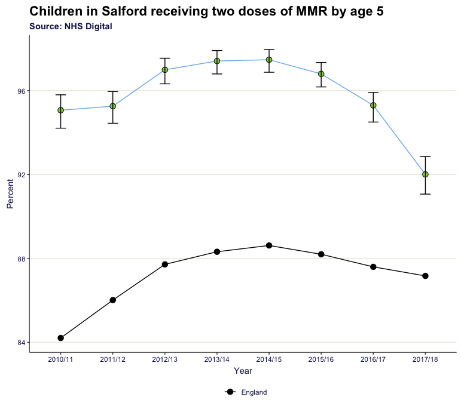

## Instructions

1. Load the necessary R packages.

```r
library(tidyverse); library(fingertipsR) ; library(fingertipscharts)
```

2. Run the `select_indicators()` function from the [fingertipsR](https://cran.r-project.org/web/packages/fingertipsR/index.html) package. Enter your search terms into the popup browser window (e.g. “MMR vaccination”) and find the corresponding **IndicatorID** in the table. Now select the row and click ‘Done’. Close the browser and return to your R session. The **IndicatorID**, in this case 30311, will be stored in the object called ‘indicator’.

```r
indicator <- select_indicators()
```

3. Now let’s have a look at the metadata for that indicator to double check it is the one we want.

```r
indicator_metadata(IndicatorID = indicator) %>% View()
```

4. Next we need to pass the **IndicatorID** to the `fingertips_data()` function to retrieve the data from the [Fingertips API](https://fingertips.phe.org.uk/api).

```r
df <- fingertips_data(IndicatorID = indicator)
```

5. We then create a string object with the name of your local authority, e.g. Salford.

```r
la <- "Salford"
```

6. Finally, we plot the indicator alongside England as a comparator in a time series chart.

```r
trends(df,
       timeperiod = Timeperiod,
       value = Value,
       area = AreaName,
       comparator = "England",
       area_name = la,
       fill = ComparedtoEnglandvalueorpercentiles,
       lowerci = LowerCI95.0limit,
       upperci = UpperCI95.0limit,
       title = paste0("Children in ", la, " receiving two doses of MMR by age 5"),
       subtitle = "Source: NHS Digital",
       xlab = "Year",
       ylab = "Percent",
       point_size = 3)
```

## Notes

A helpful guide to the other visualisations available can be found in the [fingertipscharts package vignette](https://cran.r-project.org/web/packages/fingertipscharts/vignettes/quick_charts.html).